# Iskander et al, Science Translational Medicine, 2021

Guanlin Wang

##### Figure 1. Erythroid lineage specification is preserved in bone marrow isolated from patients with RPL-DBA but not RPS-DBA.

##### load the library and object

```r
library(SingCellaR)
library(circlize)
load(file = "/Users/gwang/DBA/DBA_revision/Objects/DBA_harmony.rdata")
```

##### B) Uniform Manifold Approximation and Projection (UMAP) embedding of nineteen cell clusters generated by Louvain clustering of 41,415 CD34+Lineage (Lin)- HSPCs from 9 donors in aggregate: control (15,434 cells; 3 donors) and DBA (25,981 cells; 6 donors, 3 RPS-DBA, 3 RPL-DBA). Cell type annotation of each cluster are also shown.

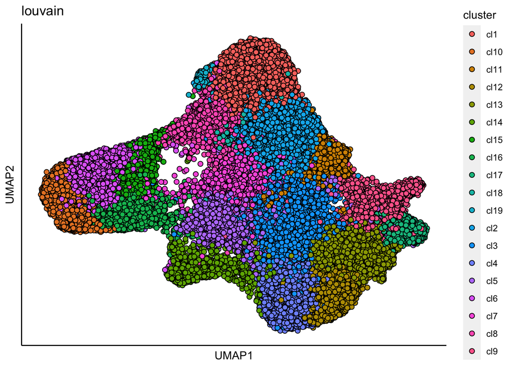

```r
plot_umap_label_by_clusters(DBA,show_method = "louvain",mark.clusters = F)
```

##### C) Force-directed graph (FDG) embedding of 6 major hematopoietic cell types in control and DBA cells is shown, colored by key marker gene sets (data file S3 and fig. S1D). Gray cells represent uncommitted cell types or cells expressing greater than 1 lineage gene set.

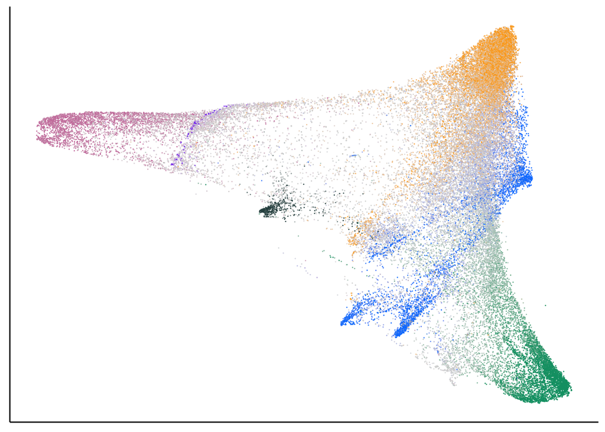

```r
plot_forceDirectedGraph_label_by_multiple_gene_sets(DBA,gmt.file = "/Users/gwang/DBA/DBA_revision/Scripts/Generating object/DBA.signature.genes.gmt",
                                                    show_gene_sets = c("Erythroid","Myeloid","Lymphoid","Megakaryocyte","HSPC","Eosinophil"),
                                                    custom_color = c("#CC79A7","#009E73","#0080FF","#7422F5","orange","darkslategray"),
                                                    isNormalizedByHouseKeeping = F,
                                                    edge.size=0,
                                                    edge.color = "#FFFFFF",
                                                    vertex.size = 0.5,
                                                    showEdge = F,
                                                    showLegend = F)
```

##### D) Circos plots and a bar plot (right) depict proportions of cells in each of 6 cell types identified by scRNAseq among total CD34+Lin- cells by donor type.

Control

```r
freq <- read.csv(file = "/Users/gwang/DBA/DBA_revision/Figures/Figure1/Freq_group.csv",header = T, sep = ",")
head(freq)
```

```
##   Celltype    RPL    RPS     WT
## 1      MyP 0.2293 0.3115 0.2071
## 2    EoMBP 0.0400 0.0245 0.0239
## 3      LyP 0.1022 0.2226 0.1390
## 4      MKP 0.0684 0.0317 0.0650
## 5       EP 0.1482 0.0548 0.1210
## 6  HSC/MPP 0.4118 0.3550 0.4440
```

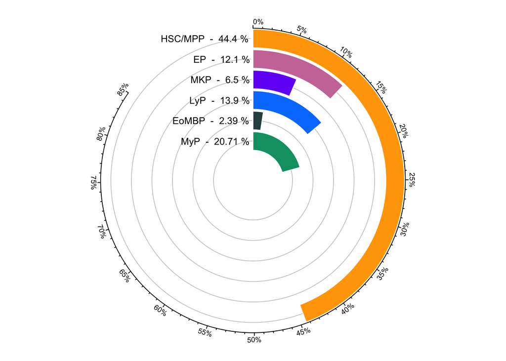

```r
celltype <- freq$Celltype
percent <- freq$WT*100
color = c("#009E73","darkslategray","#0080FF","#7422F5","#CC79A7","orange")


circos.par("start.degree" = 90, cell.padding = c(0, 0, 0, 0))
circos.initialize("a", xlim = c(0, 100))
circos.track(ylim = c(0.5, length(percent)+0.5), track.height = 0.8,
             bg.border = NA, panel.fun = function(x, y) {
               xlim = CELL_META$xlim
               circos.segments(rep(xlim[1], 6), 1:6,
                               rep(xlim[2], 6), 1:6,
                               col = "#CCCCCC")
               circos.rect(rep(0, 6), 1:6 - 0.45, percent, 1:6 + 0.45,
                           col = color, border = "white")
               circos.text(rep(xlim[1], 6), 1:6,
                           paste(celltype, " - ", percent, "%"),
                           facing = "downward", adj = c(1.05, 0.5), cex = 0.8)
               breaks = seq(0, 85, by = 5)
               circos.axis(h = "top", major.at = breaks, labels = paste0(breaks, "%"),
                           labels.cex = 0.6)
             })
```

##### D) Circos plots and a bar plot (right) depict proportions of cells in each of 6 cell types identified by scRNAseq among total CD34+Lin- cells by donor type.

RPS-DBA

```r
freq <- read.csv(file = "/Users/gwang/DBA/DBA_revision/Figures/Figure1/Freq_group.csv",header = T, sep = ",")
head(freq)
```

```
##   Celltype    RPL    RPS     WT
## 1      MyP 0.2293 0.3115 0.2071
## 2    EoMBP 0.0400 0.0245 0.0239
## 3      LyP 0.1022 0.2226 0.1390
## 4      MKP 0.0684 0.0317 0.0650
## 5       EP 0.1482 0.0548 0.1210
## 6  HSC/MPP 0.4118 0.3550 0.4440
```

```r
celltype <- freq$Celltype
percent <- freq$RPS*100
color = c("#009E73","darkslategray","#0080FF","#7422F5","#CC79A7","orange")


circos.par("start.degree" = 90, cell.padding = c(0, 0, 0, 0))
```

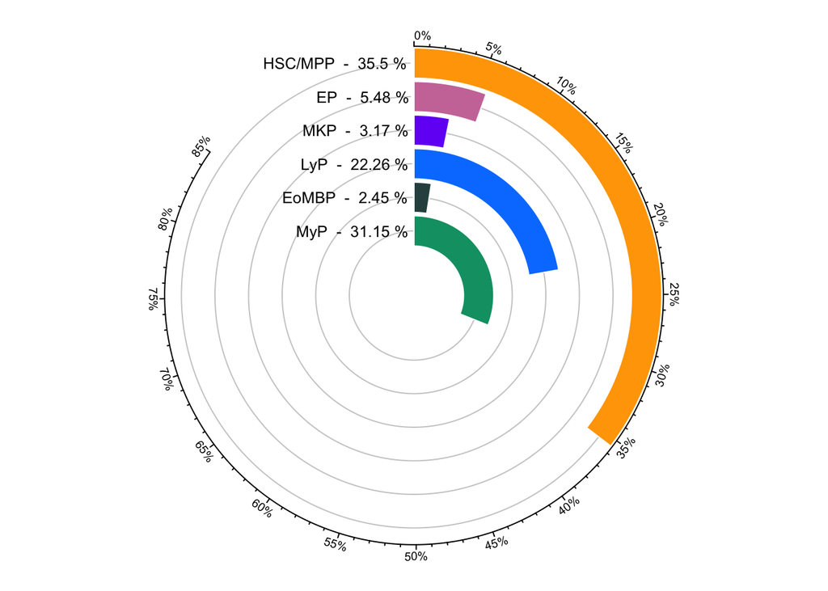

```r
circos.initialize("a", xlim = c(0, 100))
circos.track(ylim = c(0.5, length(percent)+0.5), track.height = 0.8,
             bg.border = NA, panel.fun = function(x, y) {
               xlim = CELL_META$xlim
               circos.segments(rep(xlim[1], 6), 1:6,
                               rep(xlim[2], 6), 1:6,
                               col = "#CCCCCC")
               circos.rect(rep(0, 6), 1:6 - 0.45, percent, 1:6 + 0.45,
                           col = color, border = "white")
               circos.text(rep(xlim[1], 6), 1:6,
                           paste(celltype, " - ", percent, "%"),
                           facing = "downward", adj = c(1.05, 0.5), cex = 0.8)
               breaks = seq(0, 85, by = 5)
               circos.axis(h = "top", major.at = breaks, labels = paste0(breaks, "%"),
                           labels.cex = 0.6)
             })
```

##### D) Circos plots and a bar plot (right) depict proportions of cells in each of 6 cell types identified by scRNAseq among total CD34+Lin- cells by donor type.

RPL-DBA

```r
freq <- read.csv(file = "/Users/gwang/DBA/DBA_revision/Figures/Figure1/Freq_group.csv",header = T, sep = ",")
head(freq)
```

```
##   Celltype    RPL    RPS     WT
## 1      MyP 0.2293 0.3115 0.2071
## 2    EoMBP 0.0400 0.0245 0.0239
## 3      LyP 0.1022 0.2226 0.1390
## 4      MKP 0.0684 0.0317 0.0650
## 5       EP 0.1482 0.0548 0.1210
## 6  HSC/MPP 0.4118 0.3550 0.4440
```

```r
celltype <- freq$Celltype
percent <- freq$RPL*100
color = c("#009E73","darkslategray","#0080FF","#7422F5","#CC79A7","orange")


circos.par("start.degree" = 90, cell.padding = c(0, 0, 0, 0))
```

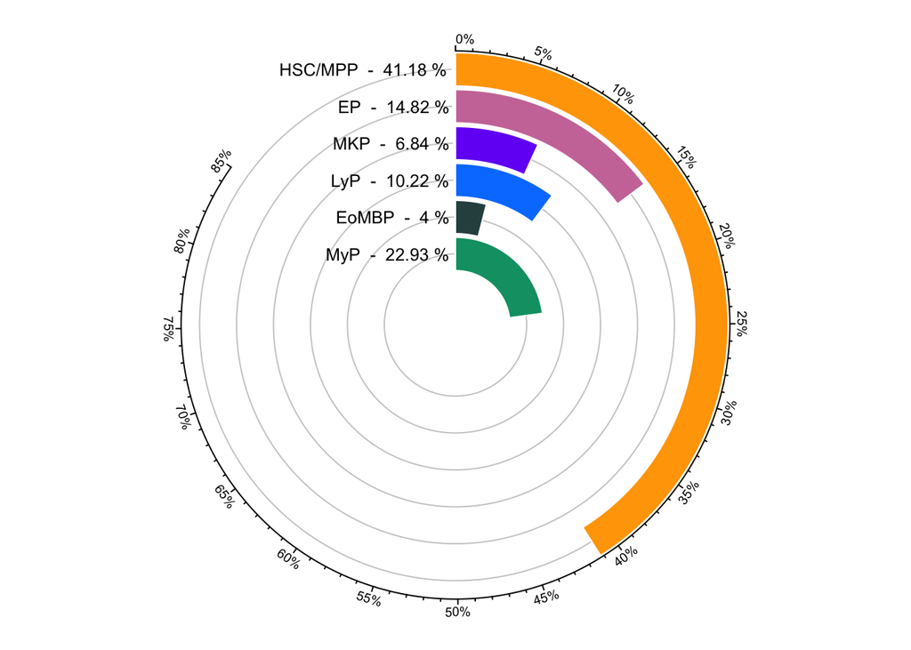

```r
circos.initialize("a", xlim = c(0, 100))
circos.track(ylim = c(0.5, length(percent)+0.5), track.height = 0.8,
             bg.border = NA, panel.fun = function(x, y) {
               xlim = CELL_META$xlim
               circos.segments(rep(xlim[1], 6), 1:6,
                               rep(xlim[2], 6), 1:6,
                               col = "#CCCCCC")
               circos.rect(rep(0, 6), 1:6 - 0.45, percent, 1:6 + 0.45,
                           col = color, border = "white")
               circos.text(rep(xlim[1], 6), 1:6,
                           paste(celltype, " - ", percent, "%"),
                           facing = "downward", adj = c(1.05, 0.5), cex = 0.8)
               breaks = seq(0, 85, by = 5)
               circos.axis(h = "top", major.at = breaks, labels = paste0(breaks, "%"),
                           labels.cex = 0.6)
             })
```